# Capstone Two: What Factors Influence Residential Property Prices in the USA?

## Step 4: Exploratory Data Analysis (EDA)

Now we analyze the data to answer our research questions. Each section below addresses one issue from our issue tree.

### Issue 1: Price Distribution — High, Mid, and Affordable Markets

**Question:** How are property prices distributed across the market?

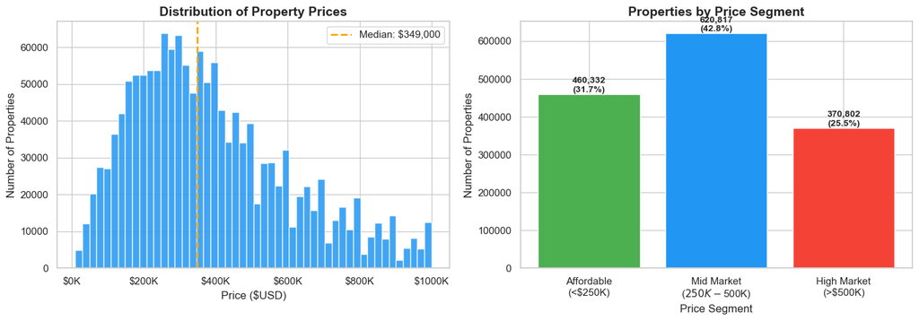

```
Chart saved!
```

```python
fig, axes = plt.subplots(1, 2, figsize=(14, 5))

# Histogram of prices
axes[0].hist(df_clean['price'], bins=50, color='#2196F3', edgecolor='white', alpha=0.85)
axes[0].set_title('Distribution of Property Prices')
axes[0].set_xlabel('Price ($USD)')
axes[0].set_ylabel('Number of Properties')
axes[0].xaxis.set_major_formatter(mticker.FuncFormatter(lambda x, _: f'${x/1000:.0f}K'))
axes[0].axvline(df_clean['price'].median(), color='orange', linewidth=2, linestyle='--', label=f"Median: ${df_clean['price'].median():,.0f}")
axes[0].legend()

# Price segments (Affordable / Mid / High)
bins_seg = [0, 250000, 500000, 1000001]
labels_seg = [
    'Affordable\n(<$250K)',
    'Mid Market\n($250K-$500K)',
    'High Market\n(>$500K)'
]
df_clean['price_segment'] = pd.cut(df_clean['price'], bins=bins_seg, labels=labels_seg)
seg_counts = df_clean['price_segment'].value_counts().sort_index()

colors_seg = ['#4CAF50', '#2196F3', '#F44336']
axes[1].bar(seg_counts.index, seg_counts.values, color=colors_seg, edgecolor='white')
axes[1].set_title('Properties by Price Segment')
axes[1].set_xlabel('Price Segment')
axes[1].set_ylabel('Number of Properties')
for i, (idx, val) in enumerate(seg_counts.items()):
    axes[1].text(i, val + 5000, f'{val:,}\n({val/len(df_clean)*100:.1f}%)', ha='center', fontsize=10, fontweight='bold')

plt.tight_layout()
plt.savefig('chart_price_distribution.png', dpi=150, bbox_inches='tight')
plt.show()
print("Chart saved!")
```

```python
# Summary statistics by segment
print("Price Segment Summary:")
print(df_clean.groupby('price_segment')['price'].agg(['count','mean','median']).round(0))
```

```
Price Segment Summary:
                            count      mean    median
price_segment
Affordable\n(<$250K)       460332  163771.0  169950.0
Mid Market\n($250K-$500K)  620817  367600.0  360000.0
High Market\n(>$500K)      370802  694169.0  665905.0
```

### Issue 2: Property Characteristics vs. Price

**Question:** Do more bedrooms, bathrooms, and larger house size lead to higher prices?

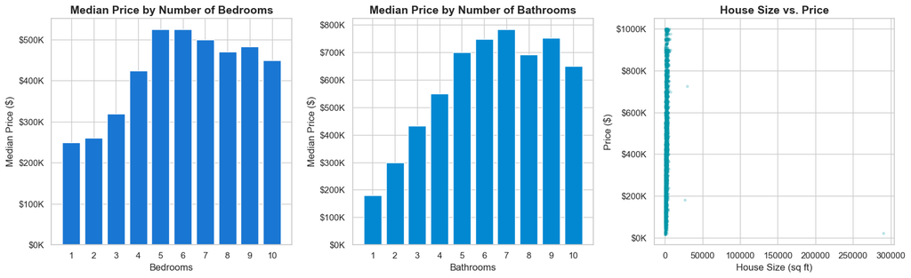

```python
fig, axes = plt.subplots(1, 3, figsize=(16, 5))

# Average price by bedrooms
bed_price = df_clean.groupby('bed')['price'].median().reset_index()
axes[0].bar(bed_price['bed'].astype(str), bed_price['price'], color='#1976D2', edgecolor='white')
axes[0].set_title('Median Price by Number of Bedrooms')
axes[0].set_xlabel('Bedrooms')
axes[0].set_ylabel('Median Price ($)')
axes[0].yaxis.set_major_formatter(mticker.FuncFormatter(lambda x, _: f'${x/1000:.0f}K'))

# Average price by bathrooms
bath_price = df_clean.groupby('bath')['price'].median().reset_index()
axes[1].bar(bath_price['bath'].astype(str), bath_price['price'], color='#0288D1', edgecolor='white')
axes[1].set_title('Median Price by Number of Bathrooms')
axes[1].set_xlabel('Bathrooms')
axes[1].set_ylabel('Median Price ($)')
axes[1].yaxis.set_major_formatter(mticker.FuncFormatter(lambda x, _: f'${x/1000:.0f}K'))

# House size vs price scatter (sample 5000 for speed)
sample = df_clean.sample(5000, random_state=42)
axes[2].scatter(sample['house_size'], sample['price'], alpha=0.2, color='#0097A7', s=8)
axes[2].set_title('House Size vs. Price')
axes[2].set_xlabel('House Size (sq ft)')
axes[2].set_ylabel('Price ($)')
axes[2].yaxis.set_major_formatter(mticker.FuncFormatter(lambda x, _: f'${x/1000:.0f}K'))

plt.tight_layout()
plt.savefig('chart_property_characteristics.png', dpi=150, bbox_inches='tight')
plt.show()
```

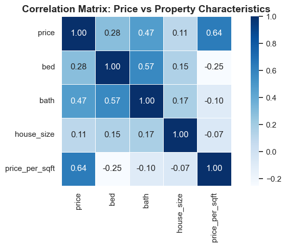

```
Correlation with Price:
price_per_sqft    0.635249
bath              0.470922
bed               0.282267
house_size        0.105703
Name: price, dtype: float64
```

```python
# Correlation between numeric variables and price
corr_cols = ['price', 'bed', 'bath', 'house_size', 'price_per_sqft']
corr_matrix = df_clean[corr_cols].corr()

plt.figure(figsize=(8, 5))
sns.heatmap(corr_matrix, annot=True, fmt='.2f', cmap='Blues',
            linewidths=0.5, square=True)
plt.title('Correlation Matrix: Price vs Property Characteristics')
plt.tight_layout()
plt.savefig('chart_correlation.png', dpi=150, bbox_inches='tight')
plt.show()

print("\nCorrelation with Price:")
print(corr_matrix['price'].drop('price').sort_values(ascending=False))
```

### Issue 3: Location Factors — State and Area Type

**Question:** Which states have the highest property prices? Does urban vs. suburban vs. rural affect price?

This directly tests our hypothesis: *does location matter more than bedrooms?*

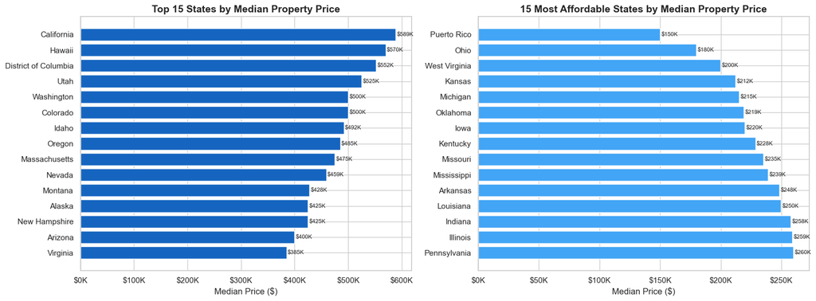

```python
# Average price by state — top 15 and bottom 15
state_price = df_clean.groupby('state')['price'].median().sort_values(ascending=False)

fig, axes = plt.subplots(1, 2, figsize=(16, 6))

# Top 15 most expensive states
top15 = state_price.head(15)
axes[0].barh(top15.index[::-1], top15.values[::-1], color='#1565C0', edgecolor='white')
axes[0].set_title('Top 15 States by Median Property Price')
axes[0].set_xlabel('Median Price ($)')
axes[0].xaxis.set_major_formatter(mticker.FuncFormatter(lambda x, _: f'${x/1000:.0f}K'))
for i, (val) in enumerate(top15.values[::-1]):
    axes[0].text(val + 2000, i, f'${val/1000:.0f}K', va='center', fontsize=8)

# Bottom 15 most affordable states
bot15 = state_price.tail(15)
axes[1].barh(bot15.index, bot15.values, color='#42A5F5', edgecolor='white')
axes[1].set_title('15 Most Affordable States by Median Property Price')
axes[1].set_xlabel('Median Price ($)')
axes[1].xaxis.set_major_formatter(mticker.FuncFormatter(lambda x, _: f'${x/1000:.0f}K'))
for i, (val) in enumerate(bot15.values):
    axes[1].text(val + 1000, i, f'${val/1000:.0f}K', va='center', fontsize=8)

plt.tight_layout()
plt.savefig('chart_state_prices.png', dpi=150, bbox_inches='tight')
plt.show()
```

```
Price by Area Type:
           Median Price  Mean Price   Count
area_type
rural          399000.0    436738.0  162252
urban          340000.0    379547.0  910411
suburban       339000.0    381228.0  379288
```

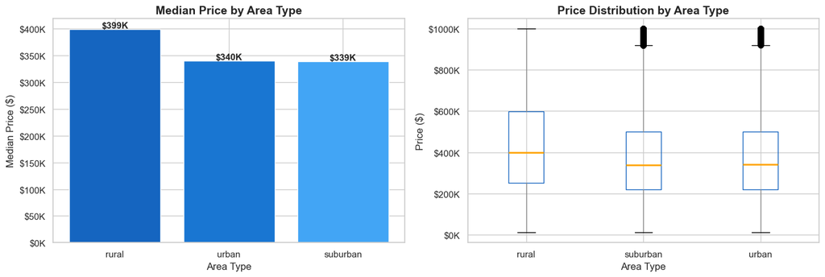

```python
# Price by area type: Urban vs Suburban vs Rural
area_stats = df_clean.groupby('area_type')['price'].agg(['median','mean','count']).round(0)
area_stats.columns = ['Median Price', 'Mean Price', 'Count']
print("Price by Area Type:")
print(area_stats.sort_values('Median Price', ascending=False))

fig, axes = plt.subplots(1, 2, figsize=(14, 5))

# Bar chart
area_median = df_clean.groupby('area_type')['price'].median().sort_values(ascending=False)
colors_area = ['#1565C0', '#1976D2', '#42A5F5']
axes[0].bar(area_median.index, area_median.values, color=colors_area, edgecolor='white')
axes[0].set_title('Median Price by Area Type')
axes[0].set_xlabel('Area Type')
axes[0].set_ylabel('Median Price ($)')
axes[0].yaxis.set_major_formatter(mticker.FuncFormatter(lambda x, _: f'${x/1000:.0f}K'))
for i, val in enumerate(area_median.values):
    axes[0].text(i, val + 2000, f'${val/1000:.0f}K', ha='center', fontweight='bold', fontsize=11)

# Box plot
df_clean.boxplot(column='price', by='area_type', ax=axes[1],
                 boxprops=dict(color='#1565C0'),
                 medianprops=dict(color='orange', linewidth=2))
axes[1].set_title('Price Distribution by Area Type')
axes[1].set_xlabel('Area Type')
axes[1].set_ylabel('Price ($)')
axes[1].yaxis.set_major_formatter(mticker.FuncFormatter(lambda x, _: f'${x/1000:.0f}K'))
plt.suptitle('')

plt.tight_layout()
plt.savefig('chart_area_type.png', dpi=150, bbox_inches='tight')
plt.show()
```